# Google Capstone Project

Author: Deuel

Date: 5th April 2022

#### **Case Study 1: How does a bike-share navigate speedy success?**

### **1.0 Ask**

#### **1.1 Identify the Business Task**

How do annual members and casual riders use Cyclistic bikes differently?

#### **1.2 Deliverables**

1. A clear statement of the business task
2. A description of all data sources used
3. Documentation of any cleaning or manipulation of data
4. A summary of your analysis
5. Supporting visualizations and key findings
6. Top three recommendations based on analysis

#### **1.3 Stakeholders**

1. Cyclistic executive team - Decides whether to approve the recommended marketing program.
2. Cyclistic marketing analytics team - Team responsible for collecting, analyzing, and reporting data that helps guide Cyclistic marketing strategy.
3. Lily Moreno - Director of marketing

### **2.0 Prepare**

#### **2.1 Data Information**

- Data can be found at this [link](https://divvy-tripdata.s3.amazonaws.com/index.html)
- We are using the latest 12 months of data (May 2021 - April 2022), with available data dating back to 2013.

#### **2.2 Data ROCCC**

The dataset provided fufills ROCCC.

### **3.0 Process**

#### **3.1 Data Understanding**

We would be using R to process the dataset.

Load libraries

```r
library(dplyr)
library(readxl)
library(rmarkdown)
library(tidyverse)
```

Importing the datasets into R

```r
May21 <- read_excel("D:/CapstonesData/Bike/202105-divvy-tripdata.xlsx")
Jun21 <- read_excel("D:/CapstonesData/Bike/202106-divvy-tripdata.xlsx")
Jul21 <- read_excel("D:/CapstonesData/Bike/202107-divvy-tripdata.xlsx")
Aug21 <- read_excel("D:/CapstonesData/Bike/202108-divvy-tripdata.xlsx")
Sep21 <- read_excel("D:/CapstonesData/Bike/202109-divvy-tripdata.xlsx")
Oct21 <- read_excel("D:/CapstonesData/Bike/202110-divvy-tripdata.xlsx")
Nov21 <- read_excel("D:/CapstonesData/Bike/202111-divvy-tripdata.xlsx")
Dec21 <- read_excel("D:/CapstonesData/Bike/202112-divvy-tripdata.xlsx")
Jan22 <- read_excel("D:/CapstonesData/Bike/202201-divvy-tripdata.xlsx")
Feb22 <- read_excel("D:/CapstonesData/Bike/202202-divvy-tripdata.xlsx")
Mar22 <- read_excel("D:/CapstonesData/Bike/202203-divvy-tripdata.xlsx")
Apr22 <- read_excel("D:/CapstonesData/Bike/202204-divvy-tripdata.xlsx")
```

Viewing the structure of April 2022 dataframe

```r
# views the attributes' datatype, number of rows, and row values
str(Apr22)
```

```
## tibble [371,249 x 13] (S3: tbl_df/tbl/data.frame)
##  $ ride_id           : chr [1:371249] "3564070EEFD12711" "0B820C7FCF22F489" "89EEEE32293F07FF" "84D4751AEB31888D" ...
##  $ rideable_type     : chr [1:371249] "electric_bike" "classic_bike" "classic_bike" "classic_bike" ...
##  $ started_at        : POSIXct[1:371249], format: "2022-04-06 17:42:48" "2022-04-24 19:23:07" ...
##  $ ended_at          : POSIXct[1:371249], format: "2022-04-06 17:54:36" "2022-04-24 19:43:17" ...
##  $ start_station_name: chr [1:371249] "Paulina St & Howard St" "Wentworth Ave & Cermak Rd" "Halsted St & Polk St" "Wentworth Ave & Cermak Rd" ...
##  $ start_station_id  : chr [1:371249] "515" "13075" "TA1307000121" "13075" ...
##  $ end_station_name  : chr [1:371249] "University Library (NU)" "Green St & Madison St" "Green St & Madison St" "Delano Ct & Roosevelt Rd" ...
##  $ end_station_id    : chr [1:371249] "605" "TA1307000120" "TA1307000120" "KA1706005007" ...
##  $ start_lat         : num [1:371249] 42 41.9 41.9 41.9 41.9 ...
##  $ start_lng         : num [1:371249] -87.7 -87.6 -87.6 -87.6 -87.6 ...
##  $ end_lat           : num [1:371249] 42.1 41.9 41.9 41.9 41.9 ...
##  $ end_lng           : num [1:371249] -87.7 -87.6 -87.6 -87.6 -87.6 ...
##  $ member_casual     : chr [1:371249] "member" "member" "member" "casual" ...
```

A brief description of the dataframe and attributes:

- Entire dataframe consists of `371,249` records and `13` attributes
- `ride_id` - Trip identifier.
- `rideable_type` - Type of bike used: `classic_bike`, `docked_bike`, and `electric_bike`. (`docked_bike` were used for quality control)
- `started_at` - Date and time when trip begun.
- `ended_at` - Date and time when trip ended.
- `start_station_name` - Name of the location where the trip begun.
- `start_station_id` - Identifier of the location where the begun.
- `end_station_name` - Name of the location where the trip ended
- `end_station_id` - Identifier of the location where the trip ended.
- `start_lat` - Latitudinal coordinates where the trip begun.
- `start_lng` - Longitudinal coordinates where the trip begun.
- `end_lat` - Latitudinal coordinates where the trip ended.
- `eng_lng` - Longitudinal coordinates where the trip ended.
- `member_casual` Binary class on a rider’s membership: `casual` or `member`.

The following errors were observed:

- Incorrect datatype for `rideable_type`, `member_casual` as both should be `factor` instead of `character.`

We will now append all the dataframes together. To identify which month a record is, a new `month` column will be added. Adding `month` column.

```r
# adds a new column 'month' with values that corresponds to each month
May21_new <- mutate(May21, month = 'may')
Jun21_new <- mutate(Jun21, month = 'june')
Jul21_new <- mutate(Jul21, month = 'july')
Aug21_new <- mutate(Aug21, month = 'august')
Sep21_new <- mutate(Sep21, month = 'september')
Oct21_new <- mutate(Oct21, month = 'october')
Nov21_new <- mutate(Nov21, month = 'november')
Dec21_new <- mutate(Dec21, month = 'december')
Jan22_new <- mutate(Jan22, month = 'january')
Feb22_new <- mutate(Feb22, month = 'february')
Mar22_new <- mutate(Mar22, month = 'march')
Apr22_new <- mutate(Apr22, month = 'april')
```

Newly added `month` has a datatype of `character`, which is to be corrected to `factor`.

Combining all the dataframes to `all_bike`

```r
# appends all 12 dataframes into a single dataframe 'all_bike'
all_bike <- rbind(May21_new, Jun21_new, Jul21_new, Aug21_new, Sep21_new, Oct21_new, Nov21_new, Dec21_new, Jan22_new, Feb22_new, Mar22_new, Apr22_new)
```

Correcting datatypes

```r
# changes the datatype of 'rideable_type', 'member_casual', 'month' to `factor`
all_bike$rideable_type <- as.factor(all_bike$rideable_type)
all_bike$member_casual <- as.factor(all_bike$member_casual)
all_bike$month <- as.factor(all_bike$month)
```

Summary of `all_bike`

```r
# shows statistical summaries and frequencies of the data
summary(all_bike)
```

```
##    ride_id                rideable_type       started_at
##  Length:5757551     classic_bike :3202784   Min.   :2021-05-01 00:00:11
##  Class :character   docked_bike  : 291391   1st Qu.:2021-07-07 14:52:45
##  Mode  :character   electric_bike:2263376   Median :2021-08-31 17:17:20
##                                             Mean   :2021-09-18 18:21:45
##                                             3rd Qu.:2021-11-03 20:25:37
##                                             Max.   :2022-04-30 23:59:54
##
##     ended_at                   start_station_name start_station_id
##  Min.   :2021-05-01 00:03:26   Length:5757551     Length:5757551
##  1st Qu.:2021-07-07 15:16:14   Class :character   Class :character
##  Median :2021-08-31 17:34:09   Mode  :character   Mode  :character
##  Mean   :2021-09-18 18:42:54
##  3rd Qu.:2021-11-03 20:38:44
##  Max.   :2022-05-02 00:35:01
##
##  end_station_name   end_station_id       start_lat       start_lng
##  Length:5757551     Length:5757551     Min.   :41.64   Min.   :-87.84
##  Class :character   Class :character   1st Qu.:41.88   1st Qu.:-87.66
##  Mode  :character   Mode  :character   Median :41.90   Median :-87.64
##                                        Mean   :41.90   Mean   :-87.65
##                                        3rd Qu.:41.93   3rd Qu.:-87.63
##                                        Max.   :45.64   Max.   :-73.80
##
##     end_lat         end_lng       member_casual          month
##  Min.   :41.39   Min.   :-88.97   casual:2536358   july     : 822410
##  1st Qu.:41.88   1st Qu.:-87.66   member:3221193   august   : 804352
##  Median :41.90   Median :-87.64                    september: 756147
##  Mean   :41.90   Mean   :-87.65                    june     : 729595
##  3rd Qu.:41.93   3rd Qu.:-87.63                    october  : 631226
##  Max.   :42.17   Max.   :-87.49                    may      : 531633
##  NA's   :4766    NA's   :4766                      (Other)  :1482188
```

We can see the quartiles for quantitative attributes and the frequency classes for factor. Missing values are also shown, but not complete.

#### **3.1.1 Missing values**

Finding out if there are any other missing values in `all_bike`

```r
# sums the missing values of each attribute
sapply(all_bike, function(x) sum(is.na(x)))
```

```
##            ride_id      rideable_type         started_at           ended_at
##                  0                  0                  0                  0
## start_station_name   start_station_id   end_station_name     end_station_id
##             790207             790204             843361             843361
##          start_lat          start_lng            end_lat            end_lng
##                  0                  0               4766               4766
##      member_casual              month
##                  0                  0
```

Here we can see the all the attributes’ corresponding missing values.

#### **3.2 Data Cleaning and Manipulation**

We will add a new row `ride_length`, calculated using the difference of `ended_at` and `start_at`. This gives us the trip duration for a record.

```r
all_bike_m1 <- mutate(

  # add new ride_length column by subtracting started_at from ended_at
  all_bike, ride_length = ended_at - started_at,

  # add new day_of_week column to show the day of the week
  day_of_week = weekdays.POSIXt(started_at)
  )

# print ride_length and day_of_week columns
select(all_bike_m1, ride_length, day_of_week)
```

```
## # A tibble: 5,757,551 x 2
##    ride_length day_of_week
##    <drtn>      <chr>
##  1  744 secs   Sunday
##  2 2695 secs   Sunday
##  3   72 secs   Sunday
##  4  913 secs   Sunday
##  5  413 secs   Sunday
##  6 1416 secs   Sunday
##  7  883 secs   Sunday
##  8 1075 secs   Wednesday
##  9  157 secs   Wednesday
## 10 1581 secs   Tuesday
## # ... with 5,757,541 more rows
```

Since the `docked_bike` value in `rideable_type` is not part of commercial data, we will be removing it. We will also change `ride_length` to a `numeric` datatype to ease future descriptive analysis, as well as change `day_of_week` datatype to `factor`.

```r
# new dataframe that does not include records with 'docked_bike'
all_bike_m2 <- subset(all_bike_m1, rideable_type != "docked_bike")

# changes the datatype of 'ride_length' to numeric
all_bike_m2$ride_length <- as.numeric(all_bike_m2$ride_length)

# changes the datatype of 'day_of_week' to factor
all_bike_m2$day_of_week <- as.factor(all_bike_m2$day_of_week)
```

Summarise cleaned dataframe `all_bike_m2`.

```r
# shows statistical summaries and frequencies of the cleaned data
summary(all_bike_m2)
```

```
##    ride_id                rideable_type       started_at
##  Length:5466160     classic_bike :3202784   Min.   :2021-05-01 00:00:11
##  Class :character   docked_bike  :      0   1st Qu.:2021-07-09 08:15:30
##  Mode  :character   electric_bike:2263376   Median :2021-09-02 18:57:58
##                                             Mean   :2021-09-20 13:52:41
##                                             3rd Qu.:2021-11-06 12:52:15
##                                             Max.   :2022-04-30 23:59:54
##
##     ended_at                   start_station_name start_station_id
##  Min.   :2021-05-01 00:03:26   Length:5466160     Length:5466160
##  1st Qu.:2021-07-09 08:29:22   Class :character   Class :character
##  Median :2021-09-02 19:15:02   Mode  :character   Mode  :character
##  Mean   :2021-09-20 14:10:31
##  3rd Qu.:2021-11-06 13:10:21
##  Max.   :2022-05-01 23:43:03
##
##  end_station_name   end_station_id       start_lat       start_lng
##  Length:5466160     Length:5466160     Min.   :41.64   Min.   :-87.84
##  Class :character   Class :character   1st Qu.:41.88   1st Qu.:-87.66
##  Mode  :character   Mode  :character   Median :41.90   Median :-87.64
##                                        Mean   :41.90   Mean   :-87.65
##                                        3rd Qu.:41.93   3rd Qu.:-87.63
##                                        Max.   :45.64   Max.   :-73.80
##
##     end_lat         end_lng       member_casual          month
##  Min.   :41.39   Min.   :-88.97   casual:2244967   july     : 764712
##  1st Qu.:41.88   1st Qu.:-87.66   member:3221193   august   : 759287
##  Median :41.90   Median :-87.64                    september: 720810
##  Mean   :41.90   Mean   :-87.65                    june     : 677879
##  3rd Qu.:41.93   3rd Qu.:-87.63                    october  : 608342
##  Max.   :42.17   Max.   :-87.49                    may      : 488280
##  NA's   :4165    NA's   :4165                      (Other)  :1446850
##   ride_length       day_of_week
##  Min.   :-3482   Friday   :772428
##  1st Qu.:  376   Monday   :700688
##  Median :  663   Saturday :928187
##  Mean   : 1070   Sunday   :799602
##  3rd Qu.: 1184   Thursday :756344
##  Max.   :93596   Tuesday  :743281
##                  Wednesday:765630
```

`all_bike_m2` summary shows `ride_length` with negative values, which needs to be removed.

```r
# new dataframe with no negative values for 'ride_length'
all_bike_m3 <- subset(all_bike_m2, ride_length >=0)
```

**Cleaning and Manipulation Summary**

- Changed `rideable_type` datatype to `factor`.
- Changed `member_casual` datatype to `factor`.
- Changed `month` datatype to `factor`.
- Added new `ride_length` column by subtracting `started_at` from `ended_at`.
- Added new `day_of_week` column to show the day of the week.
- Removed records with `docked_bike` values for `rideable_type` attribute.
- Changed `ride_length` datatype to `numeric`.
- Changed `day_of_week` datatype to `factor`.
- Removed records with negative values for `ride_length`.

### **4.0 Analyse**

#### **4.1 Descriptive Analysis**

Statistical analysis of the data.

```r
# summary statistics
summary(all_bike_m3)
```

```
##    ride_id                rideable_type       started_at
##  Length:5466025     classic_bike :3202703   Min.   :2021-05-01 00:00:11
##  Class :character   docked_bike  :      0   1st Qu.:2021-07-09 08:13:42
##  Mode  :character   electric_bike:2263322   Median :2021-09-02 18:57:30
##                                             Mean   :2021-09-20 13:52:38
##                                             3rd Qu.:2021-11-06 12:51:45
##                                             Max.   :2022-04-30 23:59:54
##
##     ended_at                   start_station_name start_station_id
##  Min.   :2021-05-01 00:03:26   Length:5466025     Length:5466025
##  1st Qu.:2021-07-09 08:27:43   Class :character   Class :character
##  Median :2021-09-02 19:14:27   Mode  :character   Mode  :character
##  Mean   :2021-09-20 14:10:28
##  3rd Qu.:2021-11-06 13:09:18
##  Max.   :2022-05-01 23:43:03
##
##  end_station_name   end_station_id       start_lat       start_lng
##  Length:5466025     Length:5466025     Min.   :41.64   Min.   :-87.84
##  Class :character   Class :character   1st Qu.:41.88   1st Qu.:-87.66
##  Mode  :character   Mode  :character   Median :41.90   Median :-87.64
##                                        Mean   :41.90   Mean   :-87.65
##                                        3rd Qu.:41.93   3rd Qu.:-87.63
##                                        Max.   :45.64   Max.   :-73.80
##
##     end_lat         end_lng       member_casual          month
##  Min.   :41.39   Min.   :-88.97   casual:2244912   july     : 764699
##  1st Qu.:41.88   1st Qu.:-87.66   member:3221113   august   : 759258
##  Median :41.90   Median :-87.64                    september: 720774
##  Mean   :41.90   Mean   :-87.65                    june     : 677874
##  3rd Qu.:41.93   3rd Qu.:-87.63                    october  : 608342
##  Max.   :42.17   Max.   :-87.49                    may      : 488278
##  NA's   :4165    NA's   :4165                      (Other)  :1446800
##   ride_length       day_of_week
##  Min.   :    0   Friday   :772420
##  1st Qu.:  376   Monday   :700678
##  Median :  663   Saturday :928176
##  Mean   : 1070   Sunday   :799543
##  3rd Qu.: 1184   Thursday :756340
##  Max.   :93596   Tuesday  :743274
##                  Wednesday:765594
```

```r
# summary statistics for month, sorted in descending
all_bike_m3 %>% count(month, sort = TRUE)
```

```
## # A tibble: 12 x 2
##    month          n
##    <fct>      <int>
##  1 july      764699
##  2 august    759258
##  3 september 720774
##  4 june      677874
##  5 october   608342
##  6 may       488278
##  7 april     359133
##  8 november  352316
##  9 march     275682
## 10 december  242612
## 11 february  114248
## 12 january   102809
```

From the above summaries, we can conclude that:  
1. Most used bike type was classic, with possibility of it being more preferred than the electric, or there are more classic in circulation.  
2. Members makes up the majority of riders, at 59%.  
3. Average duration of a ride is about 18mins.  
4. Most rides happened on a Saturday. It could be that bikes were preferred due to heavier roads, or leisure time increases the usage of bikes.  
5. Top 3 months with highest ride counts are July, August, and September, which are summer months with higher leisure activity.

### **5.0 Share**

#### **5.1 Data Visualisations**

Load ggplot2 package for data visuals

```r
library(ggplot2)
require(scales)
```

**5.1.1 Comparing Ride Durations**

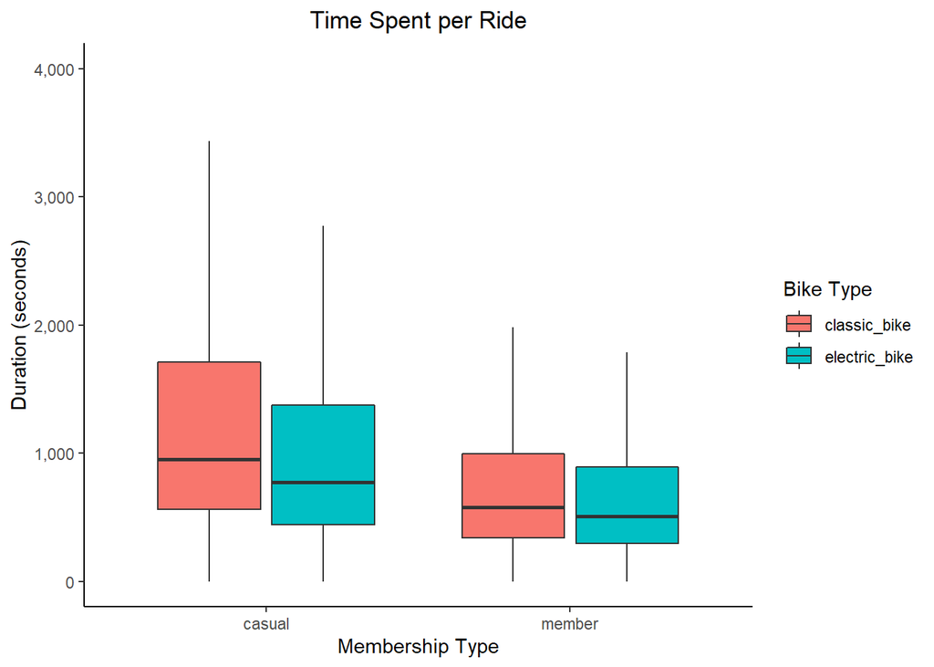

```r
ggplot(data = all_bike_m3, aes(x=member_casual, y=ride_length)) +   # set axis
  geom_boxplot(aes(fill=rideable_type), outlier.shape = NA) +       # create boxplot without outliers
  coord_cartesian(ylim = c(0, 4000)) +                              # limit y-axis values
  scale_y_continuous(labels = comma)  +                             # change y-axis labels to have commas
  xlab("Membership Type") + ylab("Duration (seconds)") +            # create axis labels
  ggtitle("Time Spent per Ride") +                                  # create title
  guides(fill=guide_legend(title="Bike Type")) +                    # create legend with title
  theme_classic() +                                                 # set theme
  theme(plot.title = element_text(hjust = 0.5))                     # center title
```

1. Distributions of all four boxplots are positively-skewed.  
2. Casual riders tend to ride more than Member Riders.  
3. Classic Bike has longer ride time than electric bike in both membership classes.  
**5.1.2 Frequency of Rides per Week**

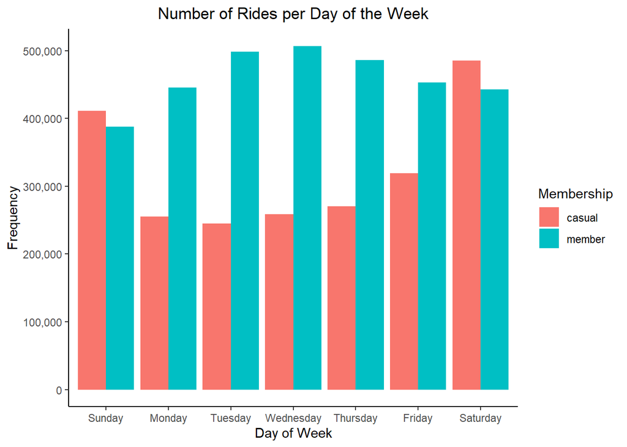

```r
# create vector for plot re-ordering
day_of_week_order <- c("Sunday", "Monday", "Tuesday", "Wednesday", "Thursday", "Friday", "Saturday")

ggplot(all_bike_m3, aes(x=day_of_week, fill=member_casual)) +   # set axis
  geom_bar(position = "dodge") +                                # create bar graph, set to grouped
  scale_x_discrete(limit=day_of_week_order) +                   # re-order x-axis based on created vector
  scale_y_continuous(labels = comma) +                          # change y-axis labels to have commas
  xlab("Day of Week") + ylab("Frequency") +                     # create axis labels
  ggtitle("Number of Rides per Day of the Week") +              # create title
  guides(fill=guide_legend(title="Membership")) +               # create legend with title
  theme_classic() +                                             # set theme
  theme(plot.title = element_text(hjust = 0.5))                 # center title
```

1. Members generally ride more often than casual riders.  
2. Casual riders ride more often on weekends, while the opposite happens for members.  
**5.1.3 Monthly Time Series on Rides for Casual Riders**

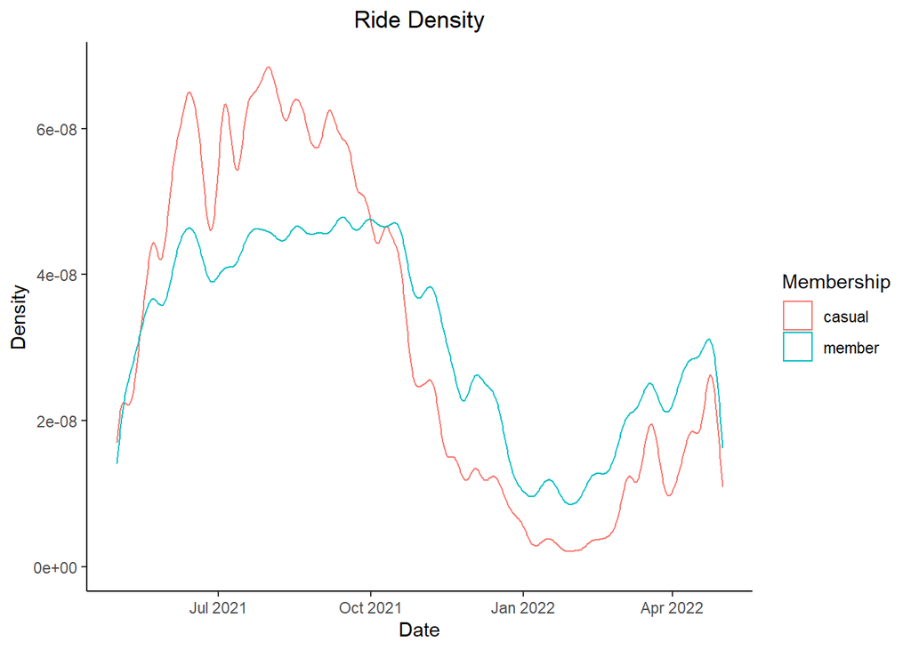

```r
ggplot(all_bike_m3, aes(x=started_at, color=member_casual)) +   # set axis
  geom_density(alpha=0.3) +                                     # create density plot
  xlab("Date") + ylab("Density") +                              # create axis labels
  ggtitle("Ride Density") +                                     # create title
  guides(color=guide_legend(title="Membership")) +              # create legend with title
  theme_classic() +                                             # set theme
  theme(plot.title = element_text(hjust = 0.5))                 # center title
```

1. Cyclical pattern - peaks late mid-year, bottoms at the start of the year. 2. Casual member demonstrates the pattern with more extreme.  
**5.1.4 Most Frequent Starting Stations for Casual Riders**

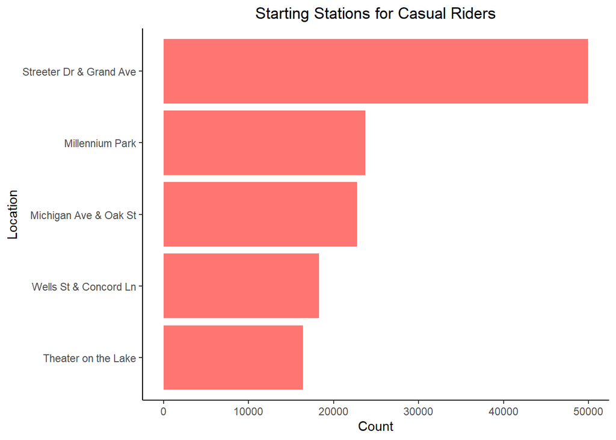

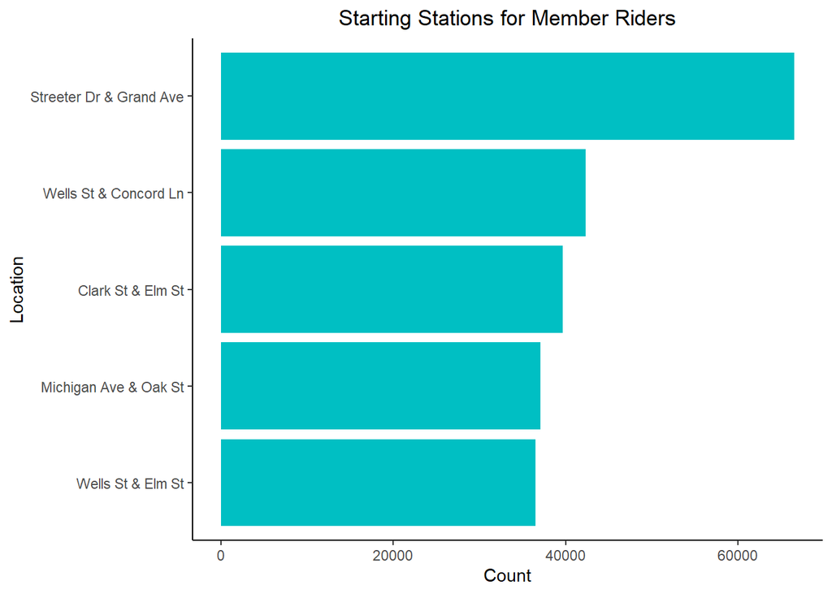

```r
# filter for casual riders with no missing values in 'start station name' attribute
all_bike_m3_casualonly <-  subset(all_bike_m3, member_casual != "member")
all_bike_m3_casual_SSN <-  subset(all_bike_m3_casualonly, !is.na(start_station_name))
# replicated same code or member riders by changing this filter for casual to members.

# sort descending and select top 5 rows
top5startstations <- all_bike_m3_casual_SSN  %>%
  count(start_station_name, sort = TRUE) %>%
  slice(1:5)

ggplot(top5startstations, aes(x=reorder(start_station_name, n), y=n)) +   # set axis
  geom_bar(stat="identity", fill="#ff7571") +                             # create bar graph, set colour
  coord_flip() +                                                          # set to horizontal graph
  xlab("Location") + ylab("Count") +                                      # create axis labels
  ggtitle("Starting Stations for Casual Riders") +                        # create title
  theme_classic() +                                                       # set theme
  theme(plot.title = element_text(hjust = 0.5))                           # center title
```

1. Both membership shares the most frequent starting station.  
2. Top 5 stations for casual riders tend to be right beside parks, while member rides tend to have a mix between being near parks and in urban areas.  
3. Data might not be representative due to large amount of missing values, hence may be biased.

### **6.0 Act**

We will now summarise our findings and present guides for future marketing programs.  
**6.1 How do annual members and casual riders use Cyclistic bikes differently**  
Comparing Casual to Member riders, Casual riders tend to:  
1. Use bikes for prolonged periods.  
2. Ride more on weekends.  
3. Have stronger ride count during June to September.  
4. Start their rides near parks.  
**6.2 Why would casual riders buy Cyclistic annual memberships?**  
Casual riders looks to be leisure individuals, who utilise the bikes for longer trips. Hence, it may be effective to offer incentives for longer rides, such as discounts after 15mins of riding. Casual rides happen more often on weekends and summer months. Creating a new membership type for periodic riders may be more effective than annual memberships; cheaper rides only on weekends/summer months.  
**6.3 How can Cyclistic use digital media to influence casual riders to become members?**  
Social media advertising should target a demographic with active individuals with cycling hobbies. Physical advertisements should be done around stations near parks.  
**6.4 Improvements and feedback**  
Data should include more information about a rider to better understand and differentiate casual and members riders.